# Model Checking - Analysis of Residuals with DHARMa

Jakob Lagenbacher

1 7 2020

# Scaled Residuals and Misspecifications of the Model

In the following, I analyze the residuals of my different models, in order to check whether I used “correct” models for my data. The main goal is to identify misspecifications of the model. I use the R-package “DHARMa”. This package relies on so-called “scaled-residuals”.

These are calculated in a three-step procedure.

1. DHARMa simulates y-values from our already fitted model with the covariates of the observations. So, for every observation we estimate “nsim”-times y-values. As a result, I have a distribution of fitted y values for every observation.
2. DHARMa calculates the empirical cumulative density functions for every observation. This function describes the observed values and their probability at the covariate combination, assuming the fitted model is correct.
3. DHARMa takes the value of the cumulative density function at the observed y-value as the scaled residual.

A scaled residual of .5 means that half the simulated values are larger than the observed y-value. A scaled residual of 1 means that none of the simulated values is larger than the observed y-value. In the following statistical tests concerning misspecifications, DHARMa makes us of the fact that the distribution of the scaled residuals is asymptotically expected to be uniform provided the model is correctly specified (Dunn). So, we test whether the scaled residuals are uniformly distributed and if this is very unlikely we conclude that the model is misspecified.

# Univariate Probit Models and DHARMa

I fitted two models with Rstanarm. One with the PA of Culex perexiguus as the dependent variable and Inundation area (500 m buffer), NDVI (500 m buffer) as well as NDVI month before (2000 m buffer) as covariates. Antoher one with PA of Anopheles troparvus as the dependent variable and the same covariates.

Then, I create a DHARMAa object. This object contains the scaled residuals. For this, I specify the following arguments: 1. 4000 simulations of fitted responses per observation(simulated response), 2. the observed responses (observedResponse), 3. the median of the 4000 simulated fitted responses which is the “expected” value of the predicted y of an observation (fittedPredictedResponse) and other arguments concerning the specific handling of the “scaled residuals”.

```r
#fitting the model for Culex perexiguus
fit_cp <- stan_glm(Cxperpre ~ IA_500 + NDVI_500 + NDVIBEF_2000 + I(NDVI_500^2) + I(NDVIBEF_2000^2) + Mes, data = train, family = binomial(link = "probit"), init_r = 1.5, seed = 333)
summary(fit_cp)

#fitting the model for Anopheles atroparvus
fit_at <- stan_glm(Anatropre ~ IA_500 + NDVI_500 + NDVIBEF_2000 + I(NDVI_500^2) + I(NDVIBEF_2000^2) + Mes, data = train, family = binomial(link = "probit"), init_r = 1.5, seed = 333)
summary(fit_at)

#Create the DHARMa-object
dharm_cp <- createDHARMa(simulatedResponse = t(posterior_predict(fit_cp)), observedResponse = fit_cp$y,
                         fittedPredictedResponse = posterior_predict(fit_cp) %>% apply(2, median), integerResponse = T, seed = 333,
                         method = "PIT")
```

## Uniform Scaled Residuals

The package provides one simple plot that summarizes all important checks of the residuals.

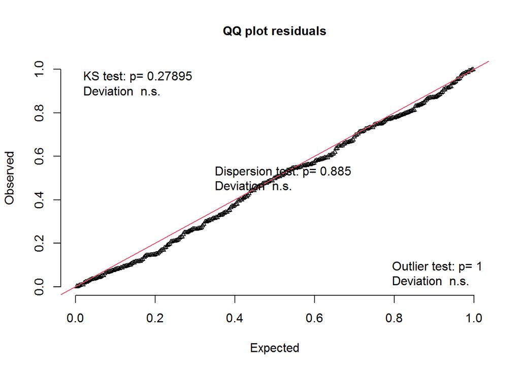

In the QQ-plot, we can eye-ball whether the scaled residuals are distributed as we would expect if the model is correctly specified. Thus, we expect the points to be on the identity line. This is the case and hence this supports the view that the model is correctly specified. Moreover, the plot gives us the results of three tests: (i) uniformity test, (ii) dispersion test and (iii) an outlier test. The latter two are not very meaningful in our setting. The dispersion test most likely will not be significant, because there is not much dispersion in 0-1 data (see Vignette). The outlier test depends on the number of simulations, because an outlier is a scaled residual of an observation that is outside the range of simulated residuals. Since I chose a large number of simulations, it is very unlikely that an observed residuals falls outside of this range. The uniformity test is a Kolmogorov-Smirnow test which tests whether the scaled residuals are drawn from a uniform distribution between 0 and 1. In this case p = 0.2789549 and thus we can maintain our 0-hypothesis that the residuals are uniformly distributed and that our model is correctly specified.

The histogramm of the residuals gives additional support.

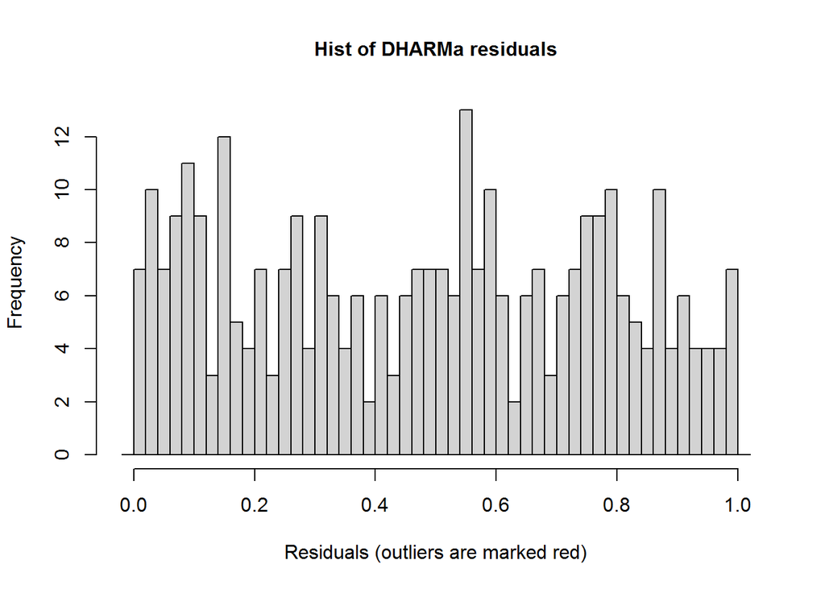

## Residuals and Covariates

To identify misspecifications, such as mistakenly treating a covariance-response relationship as linear and not quatratic, checking the relationship between residuals and covarites can be very informative. Moreover, checking this relationship might, also, reveal problems of heteroscedasticity and missing values. The following plots show the residuals against every covariate (pred on the x-axis). Moreover, quantile regressions are performed. Under a correctly specified model, we would expect, the regression lines to be straight lines with 0 slope at the respective quantiles (.25, .5 and .75). The reason is that we expect that the value of the covariate does not have an influence on the residuals.

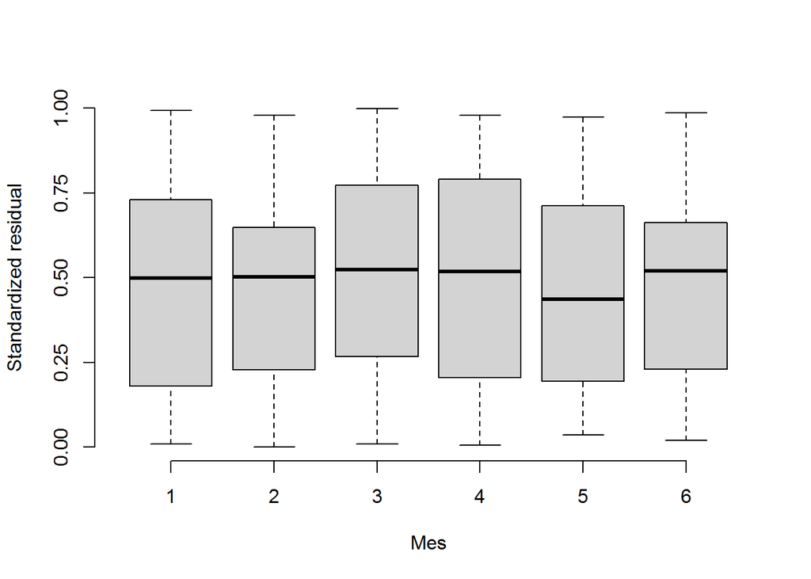

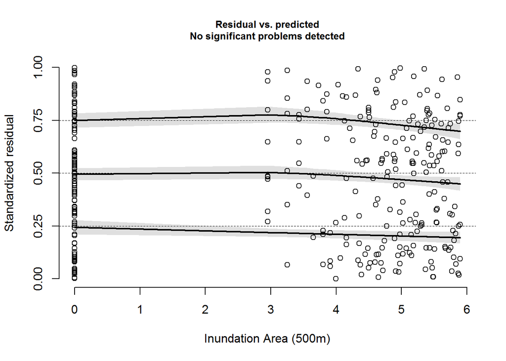

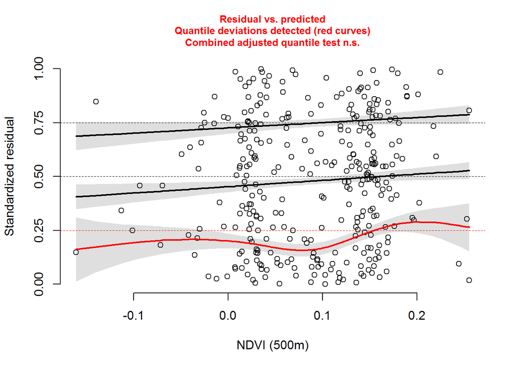

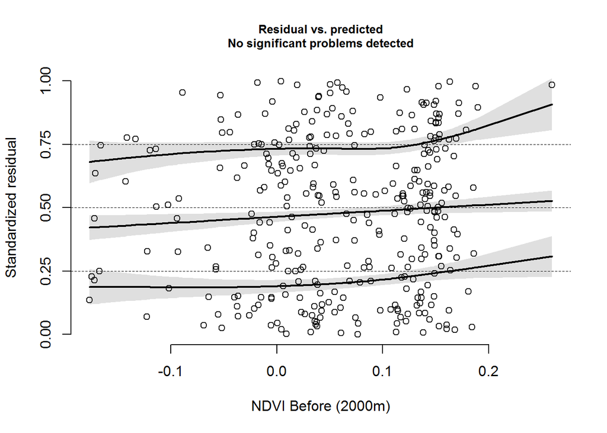

For all “Mes”, “Indundation Area” and “NDVI Before” no significant problems were detected which supports the 0-hypothesis that we specified the functional relationships of the these covariates correctly. However, for NDVI, the .25 quantile shows significant deviations from the expected distribution (a flat line). For NDVI, the relationship between residual and NDVI seems somewhat periodic. (Question: This hints at a periodic relationship between NDVI and Response, doesn’t it?).

## Temporal Autocorrelation

Temporal Autocorrelation in the residuals is a special case of dependent observations. I will test it in the following. For this, I need to recalculate the residuals according to the date of the observation. For observations on the same date, the average of the residuals will be taken as the residual for that date. This way we have a unique set of dates for which a test for temporal correlation can be run.

```r
dharm_cp_auto <- recalculateResiduals(dharm_cp, group = train$Fecha)
```

Running a Durbin-Watson test for temporal autocorrelation which tests autocorrelation at lag 1 yields an insignificant p-value:

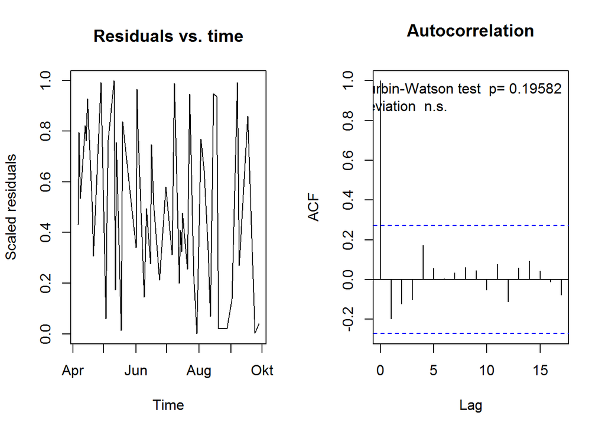

```
##
##  Durbin-Watson test
##
## data:  simulationOutput$scaledResiduals ~ 1
## DW = 2.354, p-value = 0.1958
## alternative hypothesis: true autocorrelation is not 0
```

```r
testTemporalAutocorrelation(dharm_cp_auto, time =  unique(train$Fecha))
```

Considering the AFC-plot, we see that at for all lags of 8, there is no significant temporal autocorrelation. Overall, there is no evidence for temporal autocorrelation in our residuals which supports the view that the model is correctly specified.

## Spatial Autocorrelation

To test for spatial autocorrelation with Moran’s I, I need to recalculate the residuals according to the coordinates of the observations. As in the case of temporal autocorrelation, an average per location is taken and then Moran’s I is calculated for these averages.

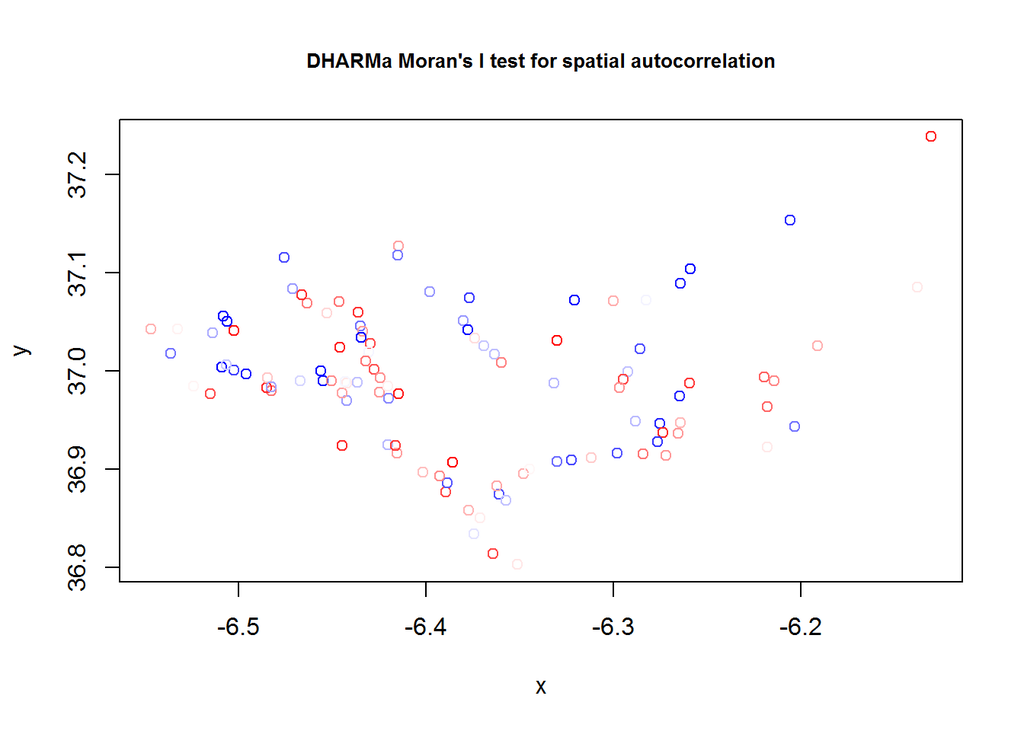

```
##
##  DHARMa Moran's I test for spatial autocorrelation
##
## data:  dharm_cp_spatial
## observed = -0.0052088, expected = -0.0092593, sd = 0.0168391, p-value =
## 0.8099
## alternative hypothesis: Spatial autocorrelation
```

```r
dharm_cp_spatial <- recalculateResiduals(dharm_cp, group = train$Norte)
testSpatialAutocorrelation(dharm_cp_spatial,
                           x =  aggregate(train$Oeste, list(train$trap), mean)$x,
                           y = aggregate(train$Norte, list(train$trap), mean)$x)
```

The Moran’s I test for spatial autocorrelation is not significant. Thus, I stick to the 0-hypothesis that there is no spatial autocorrelation.